# Expectations for Medical Statistics

- What can you expect?
- What do we expect?
- How to perform well for the exam and get most out of the course

## Who’s teaching?

[figure not shown]

(a) Jan

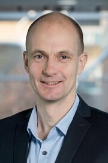

(b) Carsten

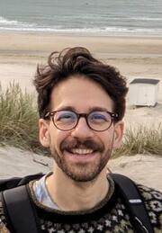

(c) Daniel

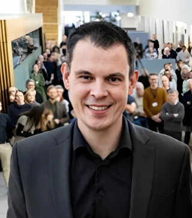

(d) Kristian

Lecturers and course responsibles

Figure 1

## Course structure

**Lectures**

- Teacher presentations
- Literature
- Exercises in R

**Workshops**

- Teacher and student presentations
- Literature
- Assignments in R

**Group project**

- Data analysis with R
- Supervision

## Code of Conduct

- Everyone should feel respected
- All questions are appreciated and will be addressed (if time allow)
- Be helpful to each other - you learn more this way
- Teachers try using appropriate tone - please call us out if we’re being boomers so we can be better!
- We dedicate a lot of time to this course but also teach other courses - please be patient with us if we do not answer email immediately

[figure not shown]

## Responsibility

**Student responsibility**

- Read material **in advance** of lecture
- Collaborate on group exercises
- Use AI for (deeper) learning

**Teacher responsibility**

- Use student feedback ASAP
- Offer help during exercises
- If you actively follow the course, you will not only pass the course but also have advantage in job market.

## How to study

**Lectures**

- Read literature **before**
- Read lecture notes **before or after**
- Teacher cover 50-75% of reading material (the most deficult part)
- **you self-study the rest**
- Exercises cover curriculum (aka exam-relevant)

**Exercises**

- Group work in class
- Teacher will help with everything we can (ask all you want)

## Getting or asking for help 🙋‍♀️🙋‍♂️

- There are lots of helpers
- Table mates, try to help out too
- We’re all learning here!
  - This is a supportive and safe environment
  - Remember our Code of Conduct
- When you are IRL use humans
- When alone at home use chat models

## Using chat models and AI

**Do**

- Prompt to explain concept differently (the teacher said “X” - can you reformulate?)
- Prompt to explain code (here is some R code - ELI5 what does it do?)
- Prompt to probe your own knowledge (give me more assignments on “X”)
- Use AI to challenge your understanding: “What assumptions am I making?”
- Ask for hints when you are stuck — before asking for the solution.

**Don’t**

- Relying on help will make you dependent (what happens when AI is not there?)
- Trust any answer. A fluent and confident answer is not necessarily a correct answer. **you are responsible** for using any code or information.
- Please use each other and the teachers - otherwise, your education might be ONLY chat model AI in the future…
- Don’t ask AI to simply solve every exercise. The solved exercise is not the goal. Learning is.
- Don’t try to teach an LLM medical statistics. It already has plenty of opinions — your job is to develop your own statistical reasoning.

> The time to make mistakes, struggle, and learn is now — not when you are responsible for patients, colleagues, or decisions in the workplace.

[figure not shown]

## More on chatmodels and AI

See the website chapter [5.2](https://danmazjen.github.io/medicinsk-statistik/pre-course/reading.html#using-ai)

**Further resources on responsible use of AI**

- [AAU: Generative AI for students](https://www.en.aub.aau.dk/students/generative-ai) — guidance on academic practice, privacy, evaluating AI, useful scenarios, prompting, and avoiding over-reliance on AI.
- [AAU: Rules for use of generative AI](https://www.studerende.aau.dk/regler-og-praktisk/regler/regler-for-brug-af-generativ-ai) — know the rules that apply to your studies and exams.
- [AAU: Scenarios for using generative AI](https://www.en.aub.aau.dk/students/generative-ai/scenarios-for-use) — examples of appropriate uses of AI for studying, understanding difficult material, and exam preparation.
- [UNESCO: Guidance for generative AI in education and research](https://www.unesco.org/en/articles/guidance-generative-ai-education-and-research) — a broader perspective on human-centred and responsible use of generative AI in education.

## The exam

**Stop-assignment**

- Hand-in of course work

This will be developed in the workshops (*important to show op*)

**Project**

- Use skills from course to do a short 1 month applied data exploration and statistical analysis
- Draw question based on curriculum

*see Appendix B on the website for an example*